# Regression result

Hao Sun

4/18/2023

### Preparation

```r
share_true %>% data.frame() %>% "colnames<-"(unique(regdat$region)) %>%
  "rownames<-"(unique(regdat$crop)) %>% pander::pander()
```

[output not shown]

The **expected profit** of crop $i$ in province $j$ and year $t$ is defined as

$$Ef_{ijt} = \tilde{y}_{ijt} (p^*_{it} - c_{ijt} )+ \tilde{d}_{ijt}$$

where:

- $p^*{it}$: averaged national expected price (yuan per kilogram) in March of the current year $t$
- $c_{ijt}$: the current cost (yuan per kilogram) of crop $i$ in province $j$ and year $t$
- $\tilde{y}_{ijt}$: the averaged yield (kilogram per mu) of crop $i$ in province $j$ in the past three years, $\{t-3, t-2, t-1\}$.
- $\tilde{d}_{ijt}$: the weighted average of subsidy (yuan per mu) of crop $i$ in province $j$ in the past two years, with $\tilde{d}_{ijt} = 0.67 * d_{ij,t-1} + 0.33 * d_{ij, t-2}$

The **true profit** of crop $i$ in province $j$ and year $t$ is defined as

$$f_{ijt} = y_{ijt}(p_{ijt} - c_{ijt} ) + d_{ijt}$$
where $p_{ijt}$ is the true province level crop price (yuan per kilogram) for crop $i$ in province $j$ and year $t$.

The expected revenue of crop $i$ in province $j$ and year $t$ is

$$r_{ijt} = \tilde{y}_{ijt} p^*_{it} + \tilde{d}_{ijt} = Ef_{ijt} + \tilde{y}_{ijt} c_{ijt}$$

The relative revenus of crop $i$ in province $j$ and year $t$ is

$$rr_{ijt} = r_{ijt}/r_{4jt}$$

### OLS regression

Suppose $s_{ijt}$ is the share of cropland area for crop $i$ in province $j$ and year $t$. Let $s_{0jt} = 1 - \sum_{i=1}^4 s_{ijt}$.

We define $z_{ijt} = \log(s_{ijt}/s_{0jt})$ as the response variable.

#### Model 1 : Use expected profit

- $u_j$: fixed effect for province $j$, assumed as time invariant.
- $\epsilon_{ijt}$: random error, assumed i.i.d. with normal distribution

#### Model 3: Use relative revenue

Expected profit against share for corn:

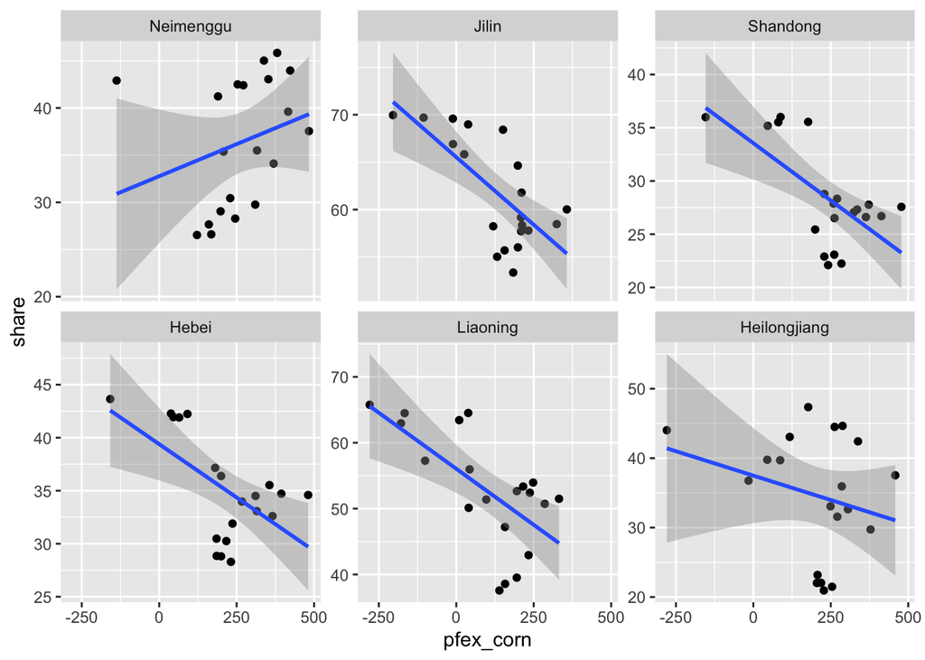

```r
ggplot(aes(x = pfex_corn, y = share), data = regdat %>% filter(crop == "corn")) + geom_point() +
  geom_smooth(method = "lm") +
  facet_wrap(~region, nrow = 2, scales = "free_y")
```

Expected revenue against share for corn:

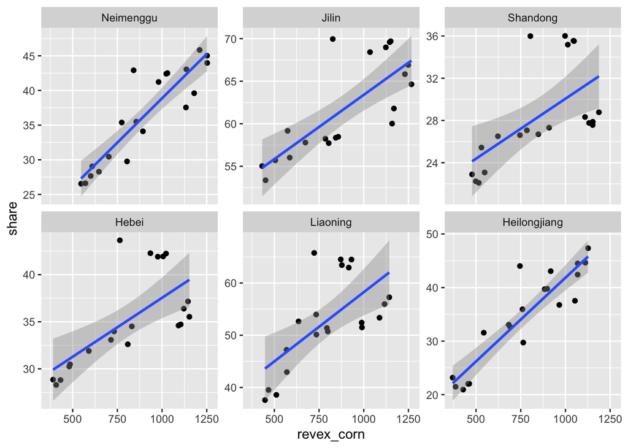

```r
ggplot(aes(x = revex_corn, y = share), data = regdat %>% filter(crop == "corn")) + geom_point() +
  geom_smooth(method = "lm") +
  facet_wrap(~region, nrow = 2, scales = "free_y")
```

Logriathm of expected revenue against share for corn:

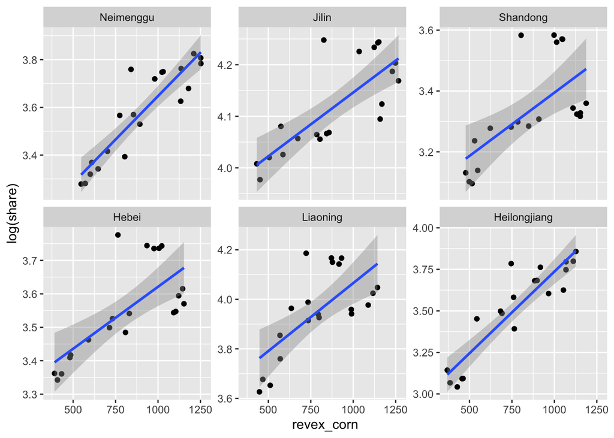

```r
ggplot(aes(x = revex_corn, y = log(share)), data = regdat %>% filter(crop == "corn")) + geom_point() +
  geom_smooth(method = "lm") +
  facet_wrap(~region, nrow = 2, scales = "free_y")
```

Logriathm of expected revenue against share for rice:

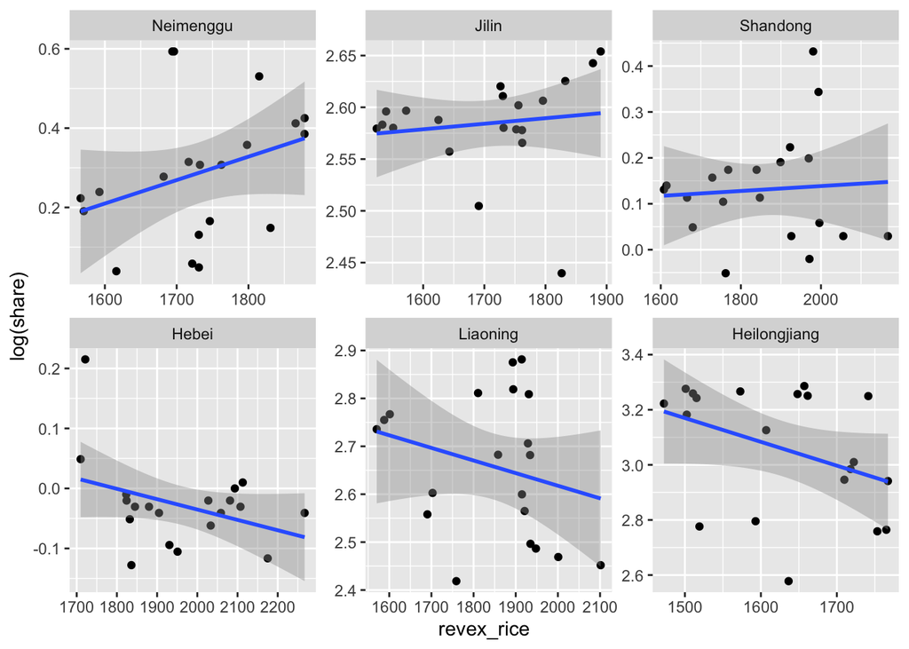

```r
ggplot(aes(x = revex_rice, y = log(share)), data = regdat %>% filter(crop == "rice")) + geom_point() +
  geom_smooth(method = "lm") +
  facet_wrap(~region, nrow = 2, scales = "free")
```

Logriathm of expected revenue against share for soybean:

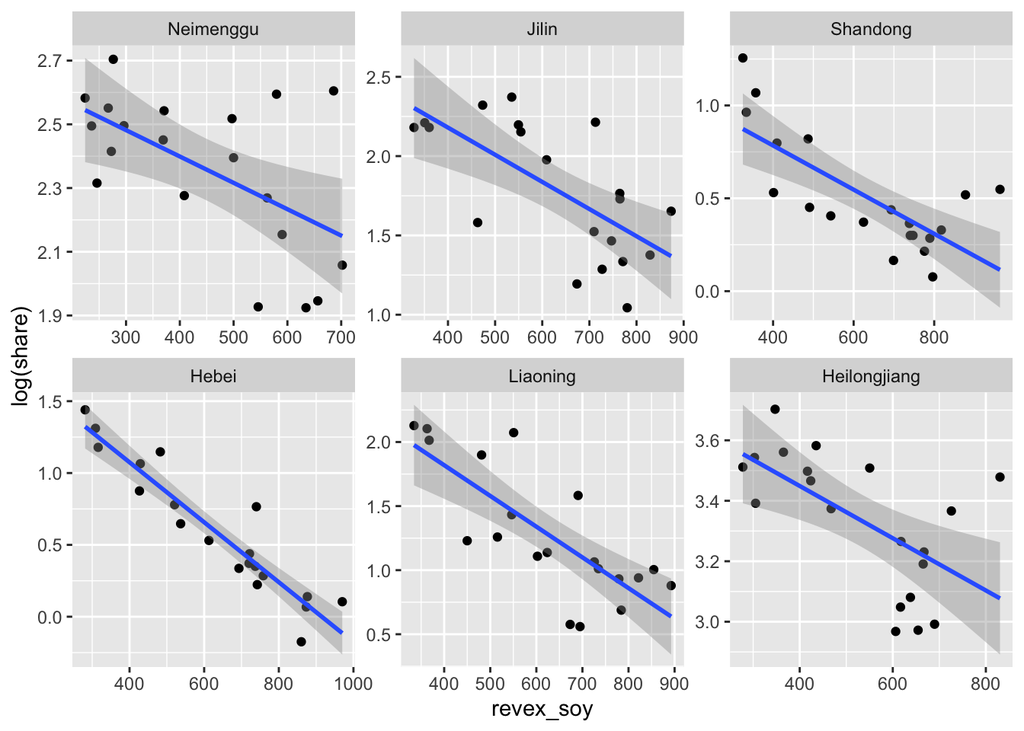

```r
ggplot(aes(x = revex_soy, y = log(share)), data = regdat %>% filter(crop == "soybean")) + geom_point() +
  geom_smooth(method = "lm") +
  facet_wrap(~region, nrow = 2, scales = "free")
```

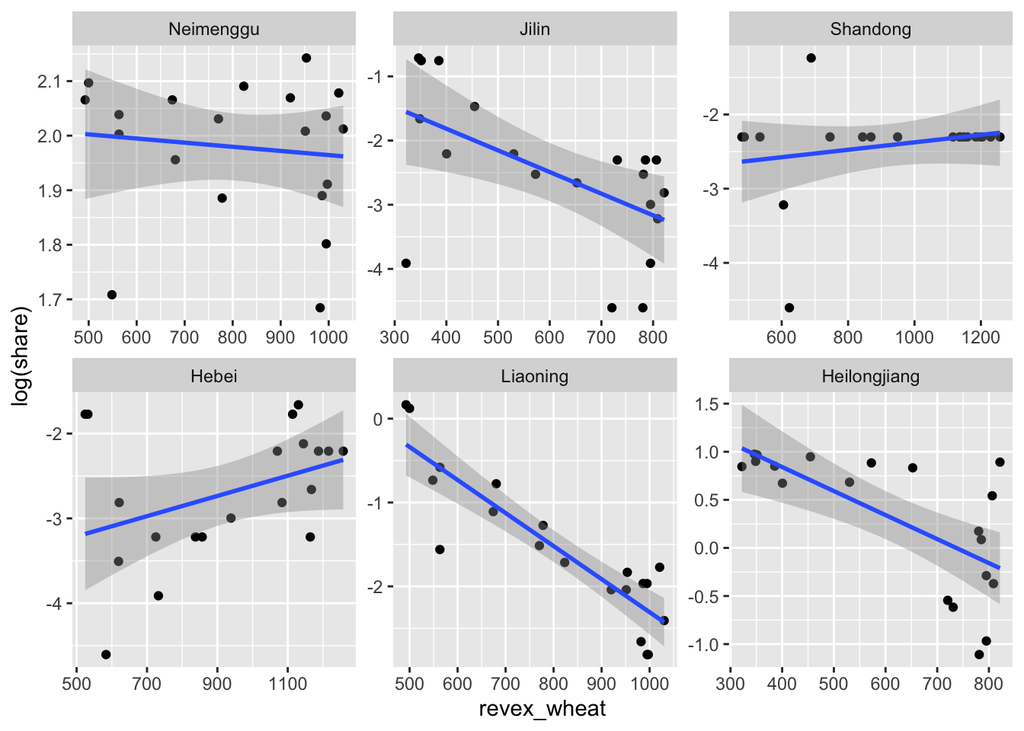

```r
ggplot(aes(x = revex_wheat, y = log(share)), data = regdat %>% filter(crop == "wheat")) + geom_point() +
  geom_smooth(method = "lm") +
  facet_wrap(~region, nrow = 2, scales = "free")
```

#### Try the two basic models

```r
lm_corn <- lm(y2 ~ 0 + pfex_corn + region,
              data = regdat %>% filter(crop == "corn"))
summary(lm_corn)
```

```
##
## Call:
## lm(formula = y2 ~ 0 + pfex_corn + region, data = regdat %>% filter(crop ==
##     "corn"))
##
## Residuals:
##      Min       1Q   Median       3Q      Max
## -1.35790 -0.19639  0.03855  0.19309  0.83966
##
## Coefficients:
##                      Estimate Std. Error t value Pr(>|t|)
## pfex_corn          -0.0010479  0.0002562  -4.090 8.12e-05 ***
## regionNeimenggu    -0.0792304  0.1136560  -0.697  0.48717
## regionJilin         1.3665012  0.0971884  14.060  < 2e-16 ***
## regionShandong     -0.6446168  0.1096872  -5.877 4.31e-08 ***
## regionHebei        -0.3517636  0.1059047  -3.322  0.00121 **
## regionLiaoning      0.7173416  0.0943665   7.602 9.29e-12 ***
## regionHeilongjiang  1.1948997  0.1050913  11.370  < 2e-16 ***
## ---
## Signif. codes:  0 '***' 0.001 '**' 0.01 '*' 0.05 '.' 0.1 ' ' 1
##
## Residual standard error: 0.4077 on 113 degrees of freedom
## Multiple R-squared:  0.8189, Adjusted R-squared:  0.8077
## F-statistic: 72.99 on 7 and 113 DF,  p-value: < 2.2e-16
```

```r
lm_corn <- lm(y2 ~ 0 + revex_corn + region,
              data = regdat %>% filter(crop == "corn"))
summary(lm_corn)
```

```
##
## Call:
## lm(formula = y2 ~ 0 + revex_corn + region, data = regdat %>%
##     filter(crop == "corn"))
##
## Residuals:
##      Min       1Q   Median       3Q      Max
## -1.00389 -0.20948  0.02826  0.17875  0.86329
##
## Coefficients:
##                      Estimate Std. Error t value Pr(>|t|)
## revex_corn          0.0011103  0.0001217   9.120 3.31e-15 ***
## regionNeimenggu    -1.3585622  0.1325234 -10.251  < 2e-16 ***
## regionJilin         0.2369209  0.1316285   1.800   0.0745 .
## regionShandong     -1.8446087  0.1279088 -14.421  < 2e-16 ***
## regionHebei        -1.4710367  0.1233351 -11.927  < 2e-16 ***
## regionLiaoning     -0.2653233  0.1219576  -2.176   0.0317 *
## regionHeilongjiang  0.1272250  0.1194302   1.065   0.2890
## ---
## Signif. codes:  0 '***' 0.001 '**' 0.01 '*' 0.05 '.' 0.1 ' ' 1
##
## Residual standard error: 0.3316 on 113 degrees of freedom
## Multiple R-squared:  0.8802, Adjusted R-squared:  0.8728
## F-statistic: 118.6 on 7 and 113 DF,  p-value: < 2.2e-16
```

#### Model 1 Regression

```r
lm_corn_pf <- lm(y2 ~ 0 + pfex_corn + pfex_rice + pfex_soy  + region,
              data = regdat %>% filter(crop == "corn"))

lm_rice_pf <- lm(y2 ~ 0 + pfex_corn + pfex_rice + pfex_soy  + region,
              data = regdat %>% filter(crop == "rice"))

lm_soy_pf <- lm(y2 ~ 0 + pfex_corn + pfex_rice + pfex_soy  + region,
              data = regdat %>% filter(crop == "soybean"))

summary(lm_corn_pf)
```

```
##
## Call:
## lm(formula = y2 ~ 0 + pfex_corn + pfex_rice + pfex_soy + region,
##     data = regdat %>% filter(crop == "corn"))
##
## Residuals:
##      Min       1Q   Median       3Q      Max
## -1.03919 -0.12332  0.01682  0.14936  0.62762
##
## Coefficients:
##                      Estimate Std. Error t value Pr(>|t|)
## pfex_corn          -7.644e-04  2.592e-04  -2.949  0.00389 **
## pfex_rice          -6.343e-04  6.212e-05 -10.209  < 2e-16 ***
## pfex_soy            5.032e-04  3.202e-04   1.572  0.11888
## regionNeimenggu     2.688e-01  9.649e-02   2.786  0.00628 **
## regionJilin         1.754e+00  7.964e-02  22.025  < 2e-16 ***
## regionShandong     -1.938e-01  9.048e-02  -2.142  0.03436 *
## regionHebei        -1.938e-02  8.328e-02  -0.233  0.81642
## regionLiaoning      1.155e+00  8.010e-02  14.415  < 2e-16 ***
## regionHeilongjiang  1.543e+00  8.524e-02  18.106  < 2e-16 ***
## ---
## Signif. codes:  0 '***' 0.001 '**' 0.01 '*' 0.05 '.' 0.1 ' ' 1
##
## Residual standard error: 0.2938 on 111 degrees of freedom
## Multiple R-squared:  0.9076, Adjusted R-squared:  0.9002
## F-statistic: 121.2 on 9 and 111 DF,  p-value: < 2.2e-16
```

```r
summary(lm_rice_pf)
```

```
##
## Call:
## lm(formula = y2 ~ 0 + pfex_corn + pfex_rice + pfex_soy + region,
##     data = regdat %>% filter(crop == "rice"))
##
## Residuals:
##      Min       1Q   Median       3Q      Max
## -1.20175 -0.16148 -0.01799  0.16273  0.85027
##
## Coefficients:
##                      Estimate Std. Error t value Pr(>|t|)
## pfex_corn          -4.370e-04  2.841e-04  -1.538    0.127
## pfex_rice          -3.681e-04  6.809e-05  -5.405 3.74e-07 ***
## pfex_soy            4.122e-04  3.510e-04   1.174    0.243
## regionNeimenggu    -3.290e+00  1.058e-01 -31.110  < 2e-16 ***
## regionJilin        -1.193e-02  8.730e-02  -0.137    0.892
## regionShandong     -3.715e+00  9.918e-02 -37.458  < 2e-16 ***
## regionHebei        -3.845e+00  9.128e-02 -42.125  < 2e-16 ***
## regionLiaoning     -3.750e-01  8.780e-02  -4.271 4.13e-05 ***
## regionHeilongjiang  8.465e-01  9.343e-02   9.060 5.20e-15 ***
## ---
## Signif. codes:  0 '***' 0.001 '**' 0.01 '*' 0.05 '.' 0.1 ' ' 1
##
## Residual standard error: 0.322 on 111 degrees of freedom
## Multiple R-squared:  0.9882, Adjusted R-squared:  0.9873
## F-statistic:  1036 on 9 and 111 DF,  p-value: < 2.2e-16
```

```r
summary(lm_soy_pf)
```

```
##
## Call:
## lm(formula = y2 ~ 0 + pfex_corn + pfex_rice + pfex_soy + region,
##     data = regdat %>% filter(crop == "soybean"))
##
## Residuals:
##      Min       1Q   Median       3Q      Max
## -1.08922 -0.16848 -0.03563  0.20739  1.09439
##
## Coefficients:
##                      Estimate Std. Error t value Pr(>|t|)
## pfex_corn          -6.253e-04  3.047e-04  -2.053  0.04247 *
## pfex_rice           2.247e-04  7.302e-05   3.078  0.00263 **
## pfex_soy            9.558e-04  3.764e-04   2.540  0.01248 *
## regionNeimenggu    -1.613e+00  1.134e-01 -14.226  < 2e-16 ***
## regionJilin        -1.261e+00  9.361e-02 -13.468  < 2e-16 ***
## regionShandong     -3.961e+00  1.064e-01 -37.240  < 2e-16 ***
## regionHebei        -3.664e+00  9.789e-02 -37.428  < 2e-16 ***
## regionLiaoning     -2.245e+00  9.415e-02 -23.842  < 2e-16 ***
## regionHeilongjiang  7.080e-01  1.002e-01   7.066 1.49e-10 ***
## ---
## Signif. codes:  0 '***' 0.001 '**' 0.01 '*' 0.05 '.' 0.1 ' ' 1
##
## Residual standard error: 0.3453 on 111 degrees of freedom
## Multiple R-squared:  0.9814, Adjusted R-squared:  0.9799
## F-statistic: 651.8 on 9 and 111 DF,  p-value: < 2.2e-16
```

#### Model 2 Regression

```r
lm_corn_rev <- lm(y2 ~ 0 + revex_corn + revex_rice + revex_soy   + region,
              data = regdat %>% filter(crop == "corn"))

lm_rice_rev <- lm(y2 ~ 0 + revex_corn + revex_rice + revex_soy  + region,
              data = regdat %>% filter(crop == "rice"))

lm_soy_rev <- lm(y2 ~ 0 + revex_corn + revex_rice + revex_soy  + region,
              data = regdat %>% filter(crop == "soybean"))


summary(lm_corn_rev)
```

```
##
## Call:
## lm(formula = y2 ~ 0 + revex_corn + revex_rice + revex_soy + region,
##     data = regdat %>% filter(crop == "corn"))
##
## Residuals:
##      Min       1Q   Median       3Q      Max
## -0.96386 -0.16715 -0.00402  0.16570  0.71084
##
## Coefficients:
##                      Estimate Std. Error t value Pr(>|t|)
## revex_corn          0.0005126  0.0002873   1.785  0.07706 .
## revex_rice          0.0004901  0.0002516   1.948  0.05394 .
## revex_soy           0.0010898  0.0003905   2.791  0.00619 **
## regionNeimenggu    -2.1537596  0.5087396  -4.234 4.76e-05 ***
## regionJilin        -0.7505007  0.4793314  -1.566  0.12026
## regionShandong     -2.9303272  0.5114062  -5.730 8.74e-08 ***
## regionHebei        -2.6349672  0.5310753  -4.962 2.54e-06 ***
## regionLiaoning     -1.3743847  0.5016314  -2.740  0.00716 **
## regionHeilongjiang -0.7890507  0.4540876  -1.738  0.08504 .
## ---
## Signif. codes:  0 '***' 0.001 '**' 0.01 '*' 0.05 '.' 0.1 ' ' 1
##
## Residual standard error: 0.3124 on 111 degrees of freedom
## Multiple R-squared:  0.8956, Adjusted R-squared:  0.8871
## F-statistic: 105.8 on 9 and 111 DF,  p-value: < 2.2e-16
```

```r
summary(lm_rice_rev)
```

```
##
## Call:
## lm(formula = y2 ~ 0 + revex_corn + revex_rice + revex_soy + region,
##     data = regdat %>% filter(crop == "rice"))
##
## Residuals:
##      Min       1Q   Median       3Q      Max
## -1.16201 -0.16127 -0.01872  0.16248  0.94597
##
## Coefficients:
##                      Estimate Std. Error t value Pr(>|t|)
## revex_corn          0.0004592  0.0003028   1.517  0.13222
## revex_rice          0.0002304  0.0002652   0.869  0.38680
## revex_soy           0.0003486  0.0004116   0.847  0.39881
## regionNeimenggu    -4.6140990  0.5362138  -8.605 5.66e-14 ***
## regionJilin        -1.3289127  0.5052175  -2.630  0.00974 **
## regionShandong     -5.1386341  0.5390245  -9.533 4.26e-16 ***
## regionHebei        -5.1943061  0.5597558  -9.280 1.63e-15 ***
## regionLiaoning     -1.6846940  0.5287218  -3.186  0.00187 **
## regionHeilongjiang -0.3827773  0.4786104  -0.800  0.42555
## ---
## Signif. codes:  0 '***' 0.001 '**' 0.01 '*' 0.05 '.' 0.1 ' ' 1
##
## Residual standard error: 0.3293 on 111 degrees of freedom
## Multiple R-squared:  0.9877, Adjusted R-squared:  0.9867
## F-statistic:   990 on 9 and 111 DF,  p-value: < 2.2e-16
```

```r
summary(lm_soy_rev)
```

```
##
## Call:
## lm(formula = y2 ~ 0 + revex_corn + revex_rice + revex_soy + region,
##     data = regdat %>% filter(crop == "soybean"))
##
## Residuals:
##      Min       1Q   Median       3Q      Max
## -1.06627 -0.16882 -0.04789  0.20707  1.19531
##
## Coefficients:
##                      Estimate Std. Error t value Pr(>|t|)
## revex_corn         -5.030e-04  3.263e-04  -1.542  0.12601
## revex_rice          1.294e-05  2.858e-04   0.045  0.96396
## revex_soy          -2.480e-05  4.436e-04  -0.056  0.95551
## regionNeimenggu    -1.129e+00  5.779e-01  -1.955  0.05315 .
## regionJilin        -6.601e-01  5.445e-01  -1.212  0.22798
## regionShandong     -3.296e+00  5.809e-01  -5.674 1.12e-07 ***
## regionHebei        -3.131e+00  6.032e-01  -5.190 9.57e-07 ***
## regionLiaoning     -1.662e+00  5.698e-01  -2.918  0.00427 **
## regionHeilongjiang  1.187e+00  5.158e-01   2.302  0.02322 *
## ---
## Signif. codes:  0 '***' 0.001 '**' 0.01 '*' 0.05 '.' 0.1 ' ' 1
##
## Residual standard error: 0.3549 on 111 degrees of freedom
## Multiple R-squared:  0.9804, Adjusted R-squared:  0.9788
## F-statistic: 616.5 on 9 and 111 DF,  p-value: < 2.2e-16
```

#### Model 3 Regression

```r
lm_corn_rr <- lm(y2 ~ 0 + rr_corn + rr_rice + region, # rc_corn + rc_rice + rc_soy +
              data = regdat %>% filter(crop == "corn"))

lm_rice_rr <- lm(y2 ~ 0 + rr_corn + rr_rice + region,
              data = regdat %>% filter(crop == "rice"))

lm_soy_rr <- lm(y2 ~ 0 +  rr_corn + rr_rice +  region,
              data = regdat %>% filter(crop == "soybean"))



summary(lm_corn_rr)
```

```
##
## Call:
## lm(formula = y2 ~ 0 + rr_corn + rr_rice + region, data = regdat %>%
##     filter(crop == "corn"))
##
## Residuals:
##      Min       1Q   Median       3Q      Max
## -1.03152 -0.19882  0.00587  0.20371  0.81244
##
## Coefficients:
##                    Estimate Std. Error t value Pr(>|t|)
## rr_corn             0.26303    0.14551   1.808  0.07335 .
## rr_rice            -0.21671    0.02263  -9.576 3.15e-16 ***
## regionNeimenggu     0.07363    0.30183   0.244  0.80772
## regionJilin         1.50897    0.20655   7.306 4.33e-11 ***
## regionShandong     -0.53800    0.20306  -2.650  0.00923 **
## regionHebei        -0.15619    0.19358  -0.807  0.42146
## regionLiaoning      0.98268    0.19122   5.139 1.18e-06 ***
## regionHeilongjiang  1.34574    0.21223   6.341 4.95e-09 ***
## ---
## Signif. codes:  0 '***' 0.001 '**' 0.01 '*' 0.05 '.' 0.1 ' ' 1
##
## Residual standard error: 0.3239 on 112 degrees of freedom
## Multiple R-squared:  0.8867, Adjusted R-squared:  0.8786
## F-statistic: 109.6 on 8 and 112 DF,  p-value: < 2.2e-16
```

```r
summary(lm_rice_rr)
```

```
##
## Call:
## lm(formula = y2 ~ 0 + rr_corn + rr_rice + region, data = regdat %>%
##     filter(crop == "rice"))
##
## Residuals:
##      Min       1Q   Median       3Q      Max
## -1.13992 -0.16813 -0.00645  0.14322  1.04495
##
## Coefficients:
##                    Estimate Std. Error t value Pr(>|t|)
## rr_corn             0.28766    0.14735   1.952  0.05341 .
## rr_rice            -0.12539    0.02292  -5.471 2.75e-07 ***
## regionNeimenggu    -3.68479    0.30564 -12.056  < 2e-16 ***
## regionJilin        -0.33472    0.20916  -1.600  0.11235
## regionShandong     -4.07821    0.20562 -19.834  < 2e-16 ***
## regionHebei        -4.08623    0.19602 -20.846  < 2e-16 ***
## regionLiaoning     -0.63940    0.19363  -3.302  0.00129 **
## regionHeilongjiang  0.54527    0.21491   2.537  0.01255 *
## ---
## Signif. codes:  0 '***' 0.001 '**' 0.01 '*' 0.05 '.' 0.1 ' ' 1
##
## Residual standard error: 0.328 on 112 degrees of freedom
## Multiple R-squared:  0.9877, Adjusted R-squared:  0.9868
## F-statistic:  1123 on 8 and 112 DF,  p-value: < 2.2e-16
```

```r
summary(lm_soy_rr)
```

```
##
## Call:
## lm(formula = y2 ~ 0 + rr_corn + rr_rice + region, data = regdat %>%
##     filter(crop == "soybean"))
##
## Residuals:
##      Min       1Q   Median       3Q      Max
## -1.12713 -0.17373 -0.04554  0.23579  1.13843
##
## Coefficients:
##                    Estimate Std. Error t value Pr(>|t|)
## rr_corn            -0.27285    0.16102  -1.695 0.092945 .
## rr_rice             0.08725    0.02504   3.484 0.000706 ***
## regionNeimenggu    -1.38992    0.33399  -4.162 6.23e-05 ***
## regionJilin        -0.98115    0.22856  -4.293 3.77e-05 ***
## regionShandong     -3.63205    0.22469 -16.164  < 2e-16 ***
## regionHebei        -3.47942    0.21420 -16.243  < 2e-16 ***
## regionLiaoning     -1.98694    0.21159  -9.390 8.44e-16 ***
## regionHeilongjiang  0.90315    0.23484   3.846 0.000200 ***
## ---
## Signif. codes:  0 '***' 0.001 '**' 0.01 '*' 0.05 '.' 0.1 ' ' 1
##
## Residual standard error: 0.3584 on 112 degrees of freedom
## Multiple R-squared:  0.9798, Adjusted R-squared:  0.9784
## F-statistic: 679.5 on 8 and 112 DF,  p-value: < 2.2e-16
```

### Model 4

use the last year’s true profit

```r
lm_corn_pftr <- lm(y2 ~ 0 + pftr_corn + pftr_rice + pftr_soy + region,
              data = regdat %>% filter(crop == "corn"))

lm_rice_pftr <- lm(y2 ~ 0 + pftr_corn + pftr_rice + pftr_soy + region,
              data = regdat %>% filter(crop == "rice"))

lm_soy_pftr <- lm(y2 ~ 0 + pftr_corn + pftr_rice + pftr_soy +  region,
              data = regdat %>% filter(crop == "soybean"))


summary(lm_corn_pftr)
```

```
##
## Call:
## lm(formula = y2 ~ 0 + pftr_corn + pftr_rice + pftr_soy + region,
##     data = regdat %>% filter(crop == "corn"))
##
## Residuals:
##      Min       1Q   Median       3Q      Max
## -1.30436 -0.19507  0.03129  0.22101  0.93408
##
## Coefficients:
##                      Estimate Std. Error t value Pr(>|t|)
## pftr_corn          -0.0013117  0.0003830  -3.425 0.000863 ***
## pftr_rice           0.0006520  0.0002688   2.425 0.016906 *
## pftr_soy            0.0003281  0.0004891   0.671 0.503726
## regionNeimenggu    -0.3619344  0.1210400  -2.990 0.003434 **
## regionJilin         1.0749908  0.1182195   9.093 4.36e-15 ***
## regionShandong     -1.0163690  0.1764786  -5.759 7.65e-08 ***
## regionHebei        -0.5512546  0.1296475  -4.252 4.44e-05 ***
## regionLiaoning      0.4592212  0.1274654   3.603 0.000473 ***
## regionHeilongjiang  0.9295764  0.1099997   8.451 1.27e-13 ***
## ---
## Signif. codes:  0 '***' 0.001 '**' 0.01 '*' 0.05 '.' 0.1 ' ' 1
##
## Residual standard error: 0.414 on 111 degrees of freedom
## Multiple R-squared:  0.8166, Adjusted R-squared:  0.8018
## F-statistic: 54.93 on 9 and 111 DF,  p-value: < 2.2e-16
```

```r
summary(lm_rice_pftr)
```

```
##
## Call:
## lm(formula = y2 ~ 0 + pftr_corn + pftr_rice + pftr_soy + region,
##     data = regdat %>% filter(crop == "rice"))
##
## Residuals:
##      Min       1Q   Median       3Q      Max
## -1.35739 -0.11351 -0.01171  0.13358  1.06087
##
## Coefficients:
##                      Estimate Std. Error t value Pr(>|t|)
## pftr_corn          -0.0006304  0.0003351  -1.881  0.06257 .
## pftr_rice           0.0002369  0.0002352   1.007  0.31608
## pftr_soy           -0.0000784  0.0004279  -0.183  0.85495
## regionNeimenggu    -3.6114894  0.1058995 -34.103  < 2e-16 ***
## regionJilin        -0.3406308  0.1034318  -3.293  0.00133 **
## regionShandong     -4.0539365  0.1544035 -26.255  < 2e-16 ***
## regionHebei        -4.0770042  0.1134304 -35.943  < 2e-16 ***
## regionLiaoning     -0.7023026  0.1115212  -6.297 6.23e-09 ***
## regionHeilongjiang  0.5394166  0.0962402   5.605 1.54e-07 ***
## ---
## Signif. codes:  0 '***' 0.001 '**' 0.01 '*' 0.05 '.' 0.1 ' ' 1
##
## Residual standard error: 0.3622 on 111 degrees of freedom
## Multiple R-squared:  0.9851, Adjusted R-squared:  0.9839
## F-statistic: 816.3 on 9 and 111 DF,  p-value: < 2.2e-16
```

```r
summary(lm_soy_pftr)
```

```
##
## Call:
## lm(formula = y2 ~ 0 + pftr_corn + pftr_rice + pftr_soy + region,
##     data = regdat %>% filter(crop == "soybean"))
##
## Residuals:
##      Min       1Q   Median       3Q      Max
## -0.85694 -0.25082  0.00201  0.25299  0.97369
##
## Coefficients:
##                      Estimate Std. Error t value Pr(>|t|)
## pftr_corn          -0.0003613  0.0003449  -1.048    0.297
## pftr_rice          -0.0003196  0.0002421  -1.320    0.189
## pftr_soy            0.0003244  0.0004404   0.737    0.463
## regionNeimenggu    -1.4376291  0.1089962 -13.190  < 2e-16 ***
## regionJilin        -1.0407374  0.1064563  -9.776  < 2e-16 ***
## regionShandong     -3.6222173  0.1589184 -22.793  < 2e-16 ***
## regionHebei        -3.4814048  0.1167472 -29.820  < 2e-16 ***
## regionLiaoning     -1.9763633  0.1147822 -17.218  < 2e-16 ***
## regionHeilongjiang  0.8927051  0.0990544   9.012 6.68e-15 ***
## ---
## Signif. codes:  0 '***' 0.001 '**' 0.01 '*' 0.05 '.' 0.1 ' ' 1
##
## Residual standard error: 0.3728 on 111 degrees of freedom
## Multiple R-squared:  0.9784, Adjusted R-squared:  0.9766
## F-statistic: 557.6 on 9 and 111 DF,  p-value: < 2.2e-16
```

### Model 5

Include relative cost

```r
lm_corn_rrrc <- lm(y2 ~ 0 + rr_corn + rr_rice + rc_corn + rc_rice + region, # rc_corn + rc_rice + rc_soy +
              data = regdat %>% filter(crop == "corn"))

lm_rice_rrrc <- lm(y2 ~ 0 + rr_corn + rr_rice + rc_corn + rc_rice + region,
              data = regdat %>% filter(crop == "rice"))

lm_soy_rrrc <- lm(y2 ~ 0 +  rr_corn + rr_rice + rc_corn + rc_rice + region,
              data = regdat %>% filter(crop == "soybean"))



summary(lm_corn_rrrc)
```

```
##
## Call:
## lm(formula = y2 ~ 0 + rr_corn + rr_rice + rc_corn + rc_rice +
##     region, data = regdat %>% filter(crop == "corn"))
##
## Residuals:
##      Min       1Q   Median       3Q      Max
## -1.07637 -0.16723  0.02708  0.20178  0.78341
##
## Coefficients:
##                    Estimate Std. Error t value Pr(>|t|)
## rr_corn             0.11780    0.14620   0.806 0.422118
## rr_rice            -0.22918    0.02201 -10.415  < 2e-16 ***
## rc_corn             0.77529    0.22914   3.384 0.000992 ***
## rc_rice            -0.22026    0.09743  -2.261 0.025749 *
## regionNeimenggu    -0.28003    0.31785  -0.881 0.380233
## regionJilin         1.05754    0.23629   4.476 1.87e-05 ***
## regionShandong     -0.98513    0.24050  -4.096 8.05e-05 ***
## regionHebei        -0.30427    0.21969  -1.385 0.168846
## regionLiaoning      0.65949    0.21193   3.112 0.002370 **
## regionHeilongjiang  1.12703    0.22593   4.988 2.29e-06 ***
## ---
## Signif. codes:  0 '***' 0.001 '**' 0.01 '*' 0.05 '.' 0.1 ' ' 1
##
## Residual standard error: 0.3087 on 110 degrees of freedom
## Multiple R-squared:  0.899,  Adjusted R-squared:  0.8898
## F-statistic: 97.89 on 10 and 110 DF,  p-value: < 2.2e-16
```

```r
summary(lm_rice_rrrc)
```

```
##
## Call:
## lm(formula = y2 ~ 0 + rr_corn + rr_rice + rc_corn + rc_rice +
##     region, data = regdat %>% filter(crop == "rice"))
##
## Residuals:
##      Min       1Q   Median       3Q      Max
## -0.98476 -0.12171 -0.00942  0.16444  0.90614
##
## Coefficients:
##                    Estimate Std. Error t value Pr(>|t|)
## rr_corn             0.12066    0.14286   0.845 0.400179
## rr_rice            -0.14281    0.02150  -6.642 1.23e-09 ***
## rc_corn             0.91768    0.22391   4.098 7.98e-05 ***
## rc_rice            -0.22719    0.09521  -2.386 0.018725 *
## regionNeimenggu    -4.18967    0.31059 -13.489  < 2e-16 ***
## regionJilin        -0.92891    0.23089  -4.023 0.000106 ***
## regionShandong     -4.68696    0.23501 -19.944  < 2e-16 ***
## regionHebei        -4.34445    0.21467 -20.238  < 2e-16 ***
## regionLiaoning     -1.08531    0.20709  -5.241 7.79e-07 ***
## regionHeilongjiang  0.21850    0.22078   0.990 0.324504
## ---
## Signif. codes:  0 '***' 0.001 '**' 0.01 '*' 0.05 '.' 0.1 ' ' 1
##
## Residual standard error: 0.3016 on 110 degrees of freedom
## Multiple R-squared:  0.9898, Adjusted R-squared:  0.9888
## F-statistic:  1064 on 10 and 110 DF,  p-value: < 2.2e-16
```

```r
summary(lm_soy_rrrc)
```

```
##
## Call:
## lm(formula = y2 ~ 0 + rr_corn + rr_rice + rc_corn + rc_rice +
##     region, data = regdat %>% filter(crop == "soybean"))
##
## Residuals:
##      Min       1Q   Median       3Q      Max
## -1.03026 -0.19850 -0.02871  0.21529  1.05740
##
## Coefficients:
##                    Estimate Std. Error t value Pr(>|t|)
## rr_corn            -0.34849    0.16428  -2.121  0.03614 *
## rr_rice             0.07214    0.02473   2.917  0.00428 **
## rc_corn             0.47698    0.25748   1.852  0.06664 .
## rc_rice            -0.04180    0.10948  -0.382  0.70338
## regionNeimenggu    -1.84875    0.35717  -5.176 1.03e-06 ***
## regionJilin        -1.42627    0.26551  -5.372 4.40e-07 ***
## regionShandong     -4.12948    0.27025 -15.280  < 2e-16 ***
## regionHebei        -3.80244    0.24686 -15.403  < 2e-16 ***
## regionLiaoning     -2.36293    0.23815  -9.922  < 2e-16 ***
## regionHeilongjiang  0.57873    0.25388   2.279  0.02457 *
## ---
## Signif. codes:  0 '***' 0.001 '**' 0.01 '*' 0.05 '.' 0.1 ' ' 1
##
## Residual standard error: 0.3468 on 110 degrees of freedom
## Multiple R-squared:  0.9814, Adjusted R-squared:  0.9797
## F-statistic: 581.5 on 10 and 110 DF,  p-value: < 2.2e-16
```

#### Prediction Results

True Result in 2021

```r
share_true %>% data.frame() %>% "colnames<-"(unique(regdat$region)) %>%
  "rownames<-"(unique(regdat$crop)[-4]) %>% pander::pander()
```

|  | Neimenggu | Jilin | Shandong | Hebei | Liaoning | Heilongjiang |
| --- | --- | --- | --- | --- | --- | --- |
| **corn** | 48.09 | 71.14 | 35.59 | 42.66 | 62.93 | 43.31 |
| **rice** | 1.77 | 13.53 | 1.03 | 0.97 | 12.03 | 25.67 |
| **soybean** | 10.22 | 4.08 | 1.67 | 0.82 | 2.4 | 25.81 |

Model 1 Prediction

```r
share_est_pf %>% data.frame() %>% "colnames<-"(unique(regdat$region)) %>%
  "rownames<-"(unique(regdat$crop)[-4]) %>% pander::pander()
```

|  | Neimenggu | Jilin | Shandong | Hebei | Liaoning | Heilongjiang |
| --- | --- | --- | --- | --- | --- | --- |
| **corn** | 41.08 | 68.4 | 37.07 | 45.23 | 61.62 | 42.5 |
| **rice** | 1.47 | 12.91 | 1.3 | 1.1 | 14.56 | 23.41 |
| **soybean** | 9.41 | 4.82 | 1.42 | 1.67 | 3.01 | 23.26 |

Model 2 Prediction

```r
share_est_rev %>% data.frame() %>% "colnames<-"(unique(regdat$region)) %>%
  "rownames<-"(unique(regdat$crop)[-4]) %>% pander::pander()
```

|  | Neimenggu | Jilin | Shandong | Hebei | Liaoning | Heilongjiang |
| --- | --- | --- | --- | --- | --- | --- |
| **corn** | 53.71 | 75.51 | 49.53 | 58.51 | 67.36 | 51.73 |
| **rice** | 1.51 | 11.44 | 1.26 | 1 | 12.65 | 23.01 |
| **soybean** | 5.8 | 2.61 | 0.89 | 0.88 | 1.94 | 15.98 |

Model 3 Prediction

```r
share_est_rr %>% data.frame() %>% "colnames<-"(unique(regdat$region)) %>%
  "rownames<-"(unique(regdat$crop)[-4]) %>% pander::pander()
```

|  | Neimenggu | Jilin | Shandong | Hebei | Liaoning | Heilongjiang |
| --- | --- | --- | --- | --- | --- | --- |
| **corn** | 48.74 | 67.97 | 35.07 | 43.26 | 58.91 | 43.2 |
| **rice** | 1.43 | 12.81 | 1.21 | 1.02 | 13.9 | 23.03 |
| **soybean** | 7.49 | 4.42 | 1.38 | 1.43 | 2.92 | 22.52 |

Model 4 Prediction

```r
share_est_pftr %>% data.frame() %>% "colnames<-"(unique(regdat$region)) %>%
  "rownames<-"(unique(regdat$crop)[-4]) %>% pander::pander()
```

|  | Neimenggu | Jilin | Shandong | Hebei | Liaoning | Heilongjiang |
| --- | --- | --- | --- | --- | --- | --- |
| **corn** | 27.75 | 58.96 | 25.59 | 35.61 | 55.77 | 32.9 |
| **rice** | 1.21 | 13.68 | 1.06 | 0.94 | 13.85 | 21.89 |
| **soybean** | 12.05 | 6.54 | 1.7 | 1.88 | 3.61 | 31.91 |

Model 5 Prediction

```r
share_est_rrrc %>% data.frame() %>% "colnames<-"(unique(regdat$region)) %>%
  "rownames<-"(unique(regdat$crop)[-4]) %>% pander::pander()
```

|  | Neimenggu | Jilin | Shandong | Hebei | Liaoning | Heilongjiang |
| --- | --- | --- | --- | --- | --- | --- |
| **corn** | 52.05 | 69.42 | 33.05 | 45.8 | 57.98 | 44.44 |
| **rice** | 1.61 | 13.49 | 1.1 | 1.1 | 13.93 | 24.23 |
| **soybean** | 8.1 | 4.24 | 1.3 | 1.46 | 3.15 | 21.43 |

#### MSE Results

```r
MSE1 <- rowMeans((share_true - share_est_pf)^2)
MSE2 <- rowMeans((share_true - share_est_rev)^2)
MSE3 <- rowMeans((share_true - share_est_rr)^2)
MSE4 <- rowMeans((share_true - share_est_pftr)^2)
MSE5 <- rowMeans((share_true - share_est_rrrc)^2)


cbind(MSE1, MSE2, MSE3, MSE4, MSE5) %>% "colnames<-"(paste0("Model", 1:5)) %>%
  "rownames<-"(unique(regdat$crop)[-4]) %>% pander::pander()
```

|  | Model1 | Model2 | Model3 | Model4 | Model5 |
| --- | --- | --- | --- | --- | --- |
| **corn** | 11.3 | 97.79 | 4.546 | 145.2 | 10.12 |
| **rice** | 2.012 | 1.992 | 1.856 | 2.99 | 0.9554 |
| **soybean** | 1.477 | 19.86 | 3.187 | 8.2 | 4.136 |